# Menstrual Cycle Prediction Tool Using Age and BMI as Secondary Predictor Variables

Author: Kai Holl

**Helpful Links**

[Research Article](https://epublications.marquette.edu/cgi/viewcontent.cgi?article=1002&context=data_nfp)

[Dataset](https://epublications.marquette.edu/data_nfp/7/)

[Dataset (Kaggle)](https://www.kaggle.com/datasets/nikitabisht/menstrual-cycle-data/data)

**Still need to do:**

- compute correlation of variables to the LengthofCycle column (age, BMI, etc.) (see Kaggle code)

# Importing required libraries

```python
import kagglehub
import math
import matplotlib.pyplot as plt
import numpy as np
import os
import pandas as pd
import pip
import seaborn as sns
import scipy
import shutil
```

```python
# import dataset
df = pd.read_csv("FedCycleData071012.csv")

df.head()
```

|  | ClientID | CycleNumber | Group | CycleWithPeakorNot | ReproductiveCategory | LengthofCycle | MeanCycleLength | EstimatedDayofOvulation | LengthofLutealPhase | FirstDayofHigh | ... | Method | Prevmethod | Methoddate | Whychart | Nextpreg | NextpregM | Spousesame | SpousesameM | Timeattemptpreg | BMI |
| --- | --- | --- | --- | --- | --- | --- | --- | --- | --- | --- | --- | --- | --- | --- | --- | --- | --- | --- | --- | --- | --- |
| 0 | nfp8122 | 1 | 0 | 1 | 0 | 29 | 27.33 | 17 | 12 | 12 | ... | 9 |  |  | 2 | 7 | 7 | 1 | 1 | 0 | 21.254724111867 |
| 1 | nfp8122 | 2 | 0 | 1 | 0 | 27 |  | 15 | 12 | 13 | ... |  |  |  |  |  |  |  |  |  |  |
| 2 | nfp8122 | 3 | 0 | 1 | 0 | 29 |  | 15 | 14 |  | ... |  |  |  |  |  |  |  |  |  |  |
| 3 | nfp8122 | 4 | 0 | 1 | 0 | 27 |  | 15 | 12 | 13 | ... |  |  |  |  |  |  |  |  |  |  |
| 4 | nfp8122 | 5 | 0 | 1 | 0 | 28 |  | 16 | 12 | 12 | ... |  |  |  |  |  |  |  |  |  |  |

5 rows × 80 columns

I also uploaded the final Final_Project.ipynb file into Session Storage in order to save it to the Final_Project .zip file that I create at the end of this file.

# Dataset characteristics

```python
df.shape
```

```
(1665, 80)
```

The current uncleaned dataframe has 1665 rows and 80 columns.

```python
df.columns
```

```
Index(['ClientID', 'CycleNumber', 'Group', 'CycleWithPeakorNot',
       'ReproductiveCategory', 'LengthofCycle', 'MeanCycleLength',
       'EstimatedDayofOvulation', 'LengthofLutealPhase', 'FirstDayofHigh',
       'TotalNumberofHighDays', 'TotalHighPostPeak', 'TotalNumberofPeakDays',
       'TotalDaysofFertility', 'TotalFertilityFormula', 'LengthofMenses',
       'MeanMensesLength', 'MensesScoreDayOne', 'MensesScoreDayTwo',
       'MensesScoreDayThree', 'MensesScoreDayFour', 'MensesScoreDayFive',
       'MensesScoreDaySix', 'MensesScoreDaySeven', 'MensesScoreDayEight',
       'MensesScoreDayNine', 'MensesScoreDayTen', 'MensesScoreDay11',
       'MensesScoreDay12', 'MensesScoreDay13', 'MensesScoreDay14',
       'MensesScoreDay15', 'TotalMensesScore', 'MeanBleedingIntensity',
       'NumberofDaysofIntercourse', 'IntercourseInFertileWindow',
       'UnusualBleeding', 'PhasesBleeding', 'IntercourseDuringUnusBleed',
       'Age', 'AgeM', 'Maristatus', 'MaristatusM', 'Yearsmarried', 'Wedding',
       'Religion', 'ReligionM', 'Ethnicity', 'EthnicityM', 'Schoolyears',
       'SchoolyearsM', 'OccupationM', 'IncomeM', 'Height', 'Weight',
       'Reprocate', 'Numberpreg', 'Livingkids', 'Miscarriages', 'Abortions',
       'Medvits', 'Medvitexplain', 'Gynosurgeries', 'LivingkidsM', 'Boys',
       'Girls', 'MedvitsM', 'MedvitexplainM', 'Urosurgeries', 'Breastfeeding',
       'Method', 'Prevmethod', 'Methoddate', 'Whychart', 'Nextpreg',
       'NextpregM', 'Spousesame', 'SpousesameM', 'Timeattemptpreg', 'BMI'],
      dtype='object')
```

```python
type(df)
```

```
pandas.core.frame.DataFrame
def __init__(data=None, index: Axes | None=None, columns: Axes | None=None, dtype: Dtype | None=None, copy: bool | None=None) -> None
```

[output not shown]

[output cut: 76 more lines]

[output not shown]

# Cleaning the dataset

## Subsetting dataset columns

First, we are going to subset the dataset to only include the variables (columns) we are interested in.

Information about these columns are listed below as well.

```python
# specifying which columns of df we want to keep
clean_df = df[["ClientID", "CycleNumber", "LengthofCycle", "MeanCycleLength", "EstimatedDayofOvulation",
             "LengthofMenses", "MeanMensesLength", "Age", "Height", "Weight", "BMI"]]
```

### Column information

**ClientID:** Randomized ID for client anonymity

The inclusion criteria for female partners of the couple participants were that they needed to be between the age of 18 and 42 years, have a stated menstrual cycle range of 21-42 days, have no history of hormonal contraceptives for the past 3 months and, if post breastfeeding, have experienced at least three cycles past weaning.

**CycleNumber:** study lasted 12-months for a potential total of 13 cycles tracked for each participant (one cycle approx. every month)

**LengthofCycle:** The menstrual cycle is the time from the first day of a woman's period to the day before her next period.

**MeanCycleLength:** Average cycle length for each client, calculated from the length of each cycle tracked.

The length of the menstrual cycle varies from woman to woman, but the average is to have periods around every 28 days.

**EstimatedDayofOvulation:** The process when an ovary releases an egg. This usually happens once per menstrual cycle, around day 14 of a 28-day cycle.

- A normal ovulation cycle lasts for about 24 hours each cycle.

**LengthofMenses:** Length of menstruation (days where bleeding occurred).

**MeanMensesLength:** Average length of menstruation, calculated from the length of each menstruation tracked.

**Demographic Variables:**

- Age
- Height
- Weight
- BMI (calculated from height & weight)

```python
clean_df["ClientID"].nunique()
```

```
159
```

```python
clean_df.shape
```

```
(1665, 11)
```

## Changing class of variables

Let's change the variable classes for all of the columns other than "ClientID" to numeric so we can conduct descriptive statistics for them.

```python
clean_df.dtypes # see type() of all columns within clean_df
```

|  | 0 |
| --- | --- |
| ClientID | object |
| CycleNumber | int64 |
| LengthofCycle | int64 |
| MeanCycleLength | object |
| EstimatedDayofOvulation | object |
| LengthofMenses | object |
| MeanMensesLength | object |
| Age | object |
| Height | object |
| Weight | object |
| BMI | object |

**dtype:** object

```python
# all columns besides ClientID need to be numeric class
cols = ["MeanCycleLength", "EstimatedDayofOvulation", "LengthofMenses", "MeanMensesLength",
        "Age", "Height", "Weight", "BMI"]
clean_df[cols] = clean_df[cols].apply(pd.to_numeric, errors='coerce') # coerce cols to numeric

clean_df.dtypes # checking work
```

|  | 0 |
| --- | --- |
| ClientID | object |
| CycleNumber | int64 |
| LengthofCycle | int64 |
| MeanCycleLength | float64 |
| EstimatedDayofOvulation | float64 |
| LengthofMenses | float64 |
| MeanMensesLength | float64 |
| Age | float64 |
| Height | float64 |
| Weight | float64 |
| BMI | float64 |

**dtype:** object

However, we don't want the "Age" column to be coded as float class.

As you can see in the below input, the values of "Age" have decimal places at the end even though this is not necessary (since "Age" is almost always considered an integer variable).

```python
clean_df["Age"].unique()
```

```
array([36., nan, 39., 29., 26., 25., 23., 33., 30., 31., 24., 27., 35.,
       37., 32., 38., 21., 34., 22., 28., 43., 41., 40., 42.])
```

Let's use the `.astype()` function to convert "Age" to an "Int64" type.

```python
clean_df["Age"] = clean_df["Age"].astype('Int64')

clean_df["Age"].unique() # checking work
```

```
<IntegerArray>
[  36, <NA>,   39,   29,   26,   25,   23,   33,   30,   31,   24,   27,   35,
   37,   32,   38,   21,   34,   22,   28,   43,   41,   40,   42]
Length: 24, dtype: Int64
```

## Changing empty values to nan

First, let's see what unique values exist for all of the variables within our clean_df DataFrame.

```python
for cols in clean_df.columns:
    print(f"{cols} : \n {clean_df[cols].unique()} \n \n")
```

```
ClientID :
 ['nfp8122' 'nfp8114' 'nfp8109' 'nfp8107' 'nfp8106' 'nfp8024' 'nfp8020'
 'nfp8026' 'nfp8030' 'nfp8031' 'nfp8032' 'nfp8034' 'nfp8036' 'nfp8040'
 'nfp8041' 'nfp8042' 'nfp8043' 'nfp8045' 'nfp8046' 'nfp8047' 'nfp8049'
 'nfp8050' 'nfp8051' 'nfp8057' 'nfp8058' 'nfp8060' 'nfp8062' 'nfp8063'
 'nfp8064' 'nfp8066' 'nfp8068' 'nfp8069' 'nfp8072' 'nfp8073' 'nfp8074'
 'nfp8076' 'nfp8079' 'nfp8080' 'nfp8083' 'nfp8085' 'nfp8087' 'nfp8091'
 'nfp8094' 'nfp8099' 'nfp8100' 'nfp8101' 'nfp8102' 'nfp8110' 'nfp8113'
 'nfp8116' 'nfp8123' 'nfp8124' 'nfp8129' 'nfp8131' 'nfp8133' 'nfp8137'
 'nfp8140' 'nfp8143' 'nfp8144' 'nfp8149' 'nfp8150' 'nfp8152' 'nfp8154'
 'nfp8155' 'nfp8159' 'nfp8161' 'nfp8164' 'nfp8165' 'nfp8168' 'nfp8172'
 'nfp8173' 'nfp8174' 'nfp8176' 'nfp8177' 'nfp8178' 'nfp8179' 'nfp8184'
 'nfp8186' 'nfp8187' 'nfp8188' 'nfp8189' 'nfp8190' 'nfp8192' 'nfp8193'
 'nfp8195' 'nfp8196' 'nfp8197' 'nfp8200' 'nfp8206' 'nfp8207' 'nfp8209'
 'nfp8210' 'nfp8211' 'nfp8212' 'nfp8218' 'nfp8221' 'nfp8223' 'nfp8226'
 'nfp8228' 'nfp8229' 'nfp8230' 'nfp8233' 'nfp8234' 'nfp8235' 'nfp8236'
 'nfp8237' 'nfp8238' 'nfp8240' 'nfp8242' 'nfp8244' 'nfp8246' 'nfp8247'
 'nfp8248' 'nfp8249' 'nfp8252' 'nfp8253' 'nfp8254' 'nfp8257' 'nfp8260'
 'nfp8263' 'nfp8264' 'nfp8266' 'nfp8268' 'nfp8269' 'nfp8270' 'nfp8271'
 'nfp8272' 'nfp8276' 'nfp8278' 'nfp8279' 'nfp8281' 'nfp8282' 'nfp8284'
 'nfp8286' 'nfp8288' 'nfp8289' 'nfp8290' 'nfp8292' 'nfp8293' 'nfp8294'
 'nfp8296' 'nfp8298' 'nfp8299' 'nfp8302' 'nfp8303' 'nfp8305' 'nfp8306'
 'nfp8308' 'nfp8309' 'nfp8310' 'nfp8311' 'nfp8312' 'nfp8313' 'nfp8317'
 'nfp8322' 'nfp8323' 'nfp8324' 'nfp8328' 'nfp8334']


CycleNumber :
 [ 1  2  3  4  5  6  7  8  9 10 11 12 13 14 15 16 17 18 19 20 21 22 23 24
 25 26 27 28 29 30 31 32 33 34 35 36 37 38 39 40 41 42 43 44 45]


LengthofCycle :
 [29 27 28 26 24 30 25 32 31 34 23 18 33 35 41 38 36 39 37 40 21 48 22 43
 45 54 42 20 44 49 19 51]


MeanCycleLength :
 [27.33   nan 31.   26.33 26.88 25.33 28.75 25.88 27.67 26.75 27.17 32.83
 33.5  32.6  29.   30.36 31.33 27.58 29.9  25.15 27.   32.   29.4  27.43
 28.77 27.62 30.64 29.67 25.8  25.23 29.5  34.07 30.92 30.25 28.46 28.15
```

[output cut: 50 more lines]

```
 29.17724609 20.11706556 20.59570312 18.00957897 25.84558824 25.7864204
 31.47761194 24.32525952 34.74765869 26.51795005 49.91715976 21.14167966
 22.31201172 38.39109431 25.82185491 20.02633701 23.17016602 35.47918835
 25.8244898  22.86030177 28.88820018 26.62878788 37.10277778 28.33963215
 34.56477627 24.79717813 21.60896951 26.62248521 18.85207612 26.25395001
 18.79260414 22.52469388 43.25160698 19.46020761 29.85651974 36.72900391
 24.36357908 26.78887574 20.49609734 35.42454019 20.52443772 20.37681159
 21.45385742 19.36639118 21.9458897  24.12662722 22.14870825 20.54623331
 18.55945822 20.67186456 19.64848159 27.97653061 25.74462891 22.88699853
 20.4660355  20.80306122 27.45401864 18.8822314  22.59412305 21.78719008
 33.46954969 25.8398307  20.17332415 21.28222656 19.73754883 19.93383743
 21.03147763 25.29136095 20.93896484 23.49075518 30.66345271 23.56509516
 20.48283039 20.94653061 23.02595112 24.68912591 25.10216227 30.26805556
 26.62285587 22.10996327 25.10186936 22.19679931 21.92470483 22.26166667
 25.68279164 34.32617188 21.63076923 24.43636886]
```

The values appearing as whitespace " " in the above output are missing values, which are present in almost all columns of the dataset.

So, let's replace them with nan to prevent confusion.

```python
# replace empty values in dataset with nan
clean_df = clean_df.replace(' ', np.nan)

# Save the updated DataFrame to the CSV file
with open("clean_df.csv", "a") as fp:  # appending to clean_df.csv
    fp.write(clean_df.to_csv(index=False))
```

Now let's find the **number** of missing values in all the columns.

```python
clean_df.isnull().sum()
```

|  | 0 |
| --- | --- |
| ClientID | 0 |
| CycleNumber | 0 |
| LengthofCycle | 0 |
| MeanCycleLength | 1524 |
| EstimatedDayofOvulation | 150 |
| LengthofMenses | 4 |
| MeanMensesLength | 1524 |
| Age | 1523 |
| Height | 1532 |
| Weight | 1531 |
| BMI | 1534 |

**dtype:** int64

```python
clean_df.shape # 1665
```

```
(1665, 11)
```

```python
# create an empty container for columns with missing values
missing_cols = []
# create an empty container for columns *without* missing values
no_missing_cols = []

# create a for loop
for cols in clean_df.columns:
    if clean_df[cols].isnull().sum() == 0:
        no_missing_cols.append(cols) # if sum of missing values is 0, add column name to no_missing_cols
    else: # if sum of missing values if not 0
        missing_cols.append(cols) # if sum of missing values is not 0, add column name to missing_cols

# print(missing_cols)
# print(no_missing_cols)

# names of columns
print("Columns WITH missing values: ", missing_cols)
print("Columns without any missing values: ", no_missing_cols)
```

```
Columns WITH missing values:  ['MeanCycleLength', 'EstimatedDayofOvulation', 'LengthofMenses', 'MeanMensesLength', 'Age', 'Height', 'Weight', 'BMI']
Columns without any missing values:  ['ClientID', 'CycleNumber', 'LengthofCycle']
```

However, it makes sense that the "MeanCycleLength", "MeanMensesLength", and demographic columns ("Age", "Height", "Weight", "BMI) having missing values, since there is only one of these values for each Client in the dataset. x Thus, the missing values within "EstimatedDayofOvulation", and "LengthofMenses" is what we are really concerned with.

```python
# find what percentage of each variable are missing values
null = clean_df.isnull().sum().sort_values(ascending=False)
null_per = ((clean_df.isnull().sum()) / (clean_df.shape[0])).sort_values(ascending=False)*100.

print(null_per)
```

```
BMI                        92.132132
Height                     92.012012
Weight                     91.951952
MeanCycleLength            91.531532
MeanMensesLength           91.531532
Age                        91.471471
EstimatedDayofOvulation     9.009009
LengthofMenses              0.240240
ClientID                    0.000000
CycleNumber                 0.000000
LengthofCycle               0.000000
dtype: float64
```

```python
clean_df.head()
```

|  | ClientID | CycleNumber | LengthofCycle | MeanCycleLength | EstimatedDayofOvulation | LengthofMenses | MeanMensesLength | Age | Height | Weight | BMI |
| --- | --- | --- | --- | --- | --- | --- | --- | --- | --- | --- | --- |
| 0 | nfp8122 | 1 | 29 | 27.33 | 17.0 | 5.0 | 4.49 | 36 | 63.0 | 120.0 | 21.254724 |
| 1 | nfp8122 | 2 | 27 | NaN | 15.0 | 5.0 | NaN | <NA> | NaN | NaN | NaN |
| 2 | nfp8122 | 3 | 29 | NaN | 15.0 | 5.0 | NaN | <NA> | NaN | NaN | NaN |
| 3 | nfp8122 | 4 | 27 | NaN | 15.0 | 5.0 | NaN | <NA> | NaN | NaN | NaN |
| 4 | nfp8122 | 5 | 28 | NaN | 16.0 | 5.0 | NaN | <NA> | NaN | NaN | NaN |

# Creating a Demographics DataFrame

## Demographic Variables

Before we create a new demographics DataFrame, let's first see if we can reduce the number of missing values in the demographic columns.

As you can see in the below output, despite the fact that BMI is calculated from Height and Weight, there is slightly more missing BMI values (1534) than in either the Height (1532) or Weight (1531) columns.

So, let's write some code that will calculate the BMI for each Client to ensure that any missing BMI values will be filled.

```python
clean_df.isnull().sum()
```

|  | 0 |
| --- | --- |
| ClientID | 0 |
| CycleNumber | 0 |
| LengthofCycle | 0 |
| MeanCycleLength | 1524 |
| EstimatedDayofOvulation | 150 |
| LengthofMenses | 4 |
| MeanMensesLength | 1524 |
| Age | 1523 |
| Height | 1532 |
| Weight | 1531 |
| BMI | 1534 |

**dtype:** int64

Since the values of the "Height" and "Weight" columns are in the US customary units (pounds (lbs) and inches), we can calculate BMI for each row using the following formula:

**US customary units: BMI = weight (pounds) / [height (in)]^2 x 703**

Source: [CDC, What Is Body Mass Index (BMI)?](https://www.cdc.gov/growth-chart-training/hcp/using-bmi/body-mass-index.html)

Written in code, that formula looks like this:

```python
clean_df["BMI"] = round((clean_df["Weight"] / (clean_df["Height"] ** 2) * 703), 2)
```

After calculating BMI for each row, it now looks like the "BMI" column only has 1532 missing values instead of 1534!

```python
clean_df.isnull().sum()
```

|  | 0 |
| --- | --- |
| ClientID | 0 |
| CycleNumber | 0 |
| LengthofCycle | 0 |
| MeanCycleLength | 1524 |
| EstimatedDayofOvulation | 150 |
| LengthofMenses | 4 |
| MeanMensesLength | 1524 |
| Age | 1523 |
| Height | 1532 |
| Weight | 1531 |
| BMI | 1532 |

**dtype:** int64

```python
clean_df = clean_df.drop(["Height", "Weight"], axis = 1)
# axis 0 = rows, axis 1 = columns

# checking work
clean_df.columns
```

```
Index(['ClientID', 'CycleNumber', 'LengthofCycle', 'MeanCycleLength',
       'EstimatedDayofOvulation', 'LengthofMenses', 'MeanMensesLength', 'Age',
       'BMI'],
      dtype='object')
```

### Adding age and BMI variables

Since we want to use the variables Age and BMI as secondary variables for menstrual cycle prediction, let's also create a new DataFrame where every row is a single ClientID with 2 columns, the age and BMI of each client.

```python
# create new table that only contains ClientID and Age & BMI (Height/Weight) columns
dems = clean_df[["ClientID", "Age", "BMI"]]

# convert to pandas DataFrame
dems = dems.reset_index()

# checking work
# --------------
# dems.head()
# dems.shape # 1665, 4

print(dems)
```

```
      index ClientID   Age    BMI
0         0  nfp8122    36  21.25
1         1  nfp8122  <NA>    NaN
2         2  nfp8122  <NA>    NaN
3         3  nfp8122  <NA>    NaN
4         4  nfp8122  <NA>    NaN
...     ...      ...   ...    ...
1660   1660  nfp8334  <NA>    NaN
1661   1661  nfp8334  <NA>    NaN
1662   1662  nfp8334  <NA>    NaN
1663   1663  nfp8334  <NA>    NaN
1664   1664  nfp8334  <NA>    NaN

[1665 rows x 4 columns]
```

**QUESTION:** I'm not sure how to "shrink" the newly created "dems" dataframe so that there are no repeated ClientID (like in the "wide_df" dataframe) while also not accidentally removing any ClientIDs.

Using the below .dropna function results in only 138 ClientIDs when there should be 159.

```python
# dems.dropna(subset = ["Age", "Height", "Weight", "BMI"], how = "all", inplace = True)
```

```python
# dems["ClientID"].nunique() # 159
```

# Descriptive statistics

## Menstrual Cycle Length

```python
print("The average menstrual cycle length of the entire sample is", round(clean_df["LengthofCycle"].mean(), 2), "days.")
print("The mean menstruation length of the entire sample is", round(clean_df["LengthofMenses"].mean(), 2), "days.")
print("The average estimated day of ovulation for the entire sample is on the", round(clean_df["EstimatedDayofOvulation"].mean(), 2), "day of the cycle.")
```

```
The average menstrual cycle length of the entire sample is 29.3 days.
The mean menstruation length of the entire sample is 5.24 days.
The average estimated day of ovulation for the entire sample is on the 15.96 day of the cycle.
```

The average menstrual cycle length of the sample if 29.3 days. This is consistent with previous observations on the typical menstrual cycle length in other populations, which averages out at around 28 days. However, the current sample's average is slightly higher, at about 1.3 days longer.

### BMI

```python
clean_df["BMI"].unique()
```

```
array([21.25,   nan, 28.13, 29.05, 27.89, 24.96, 25.79, 21.45, 22.46,
       21.95, 22.63, 24.14, 18.78, 19.2 , 29.95, 29.29, 24.1 , 30.11,
       27.41, 37.76, 16.83, 38.97, 19.97, 34.78, 29.18, 20.12, 20.6 ,
       18.01, 25.85, 31.48, 24.33, 34.75, 26.52, 49.92, 21.14, 22.31,
       38.39, 25.82, 20.03, 23.17, 35.48, 22.86, 28.89, 26.63, 37.1 ,
       28.34, 34.56, 24.8 , 21.61, 26.62, 18.85, 26.25, 18.79, 22.52,
       43.25, 19.46, 29.86, 36.73, 24.36, 26.79, 20.5 , 35.42, 20.52,
       20.38, 19.37, 24.13, 22.15, 20.55, 18.56, 20.67, 19.65, 27.98,
       25.74, 22.89, 20.47, 20.8 , 27.45, 18.88, 22.59, 21.79, 33.47,
       25.84, 20.17, 21.28, 19.74, 19.93, 21.03, 25.29, 20.94, 23.49,
       30.66, 23.57, 20.48, 20.95, 23.03, 24.69, 25.1 , 30.27, 22.11,
       22.2 , 21.92, 22.26, 25.68, 34.33, 21.63, 24.44, 24.21, 19.48])
```

```python
print("The lowest BMI score in the dataset is", clean_df['BMI'].min())
print("The highest BMI score in the dataset is", clean_df['BMI'].max())
```

```
The lowest BMI score in the dataset is 16.83
The highest BMI score in the dataset is 49.92
```

```python
clean_df["BMI"].nunique()
```

```
107
```

There are 107 unique BMI scores in the clean_df DataFrame, with scores ranging from 16.83 at the lowest to 49.92 at the highest.

**BMI Categories**

Based on categorization by the Centers for Disease Control and Prevention (CDC), BMI scores for adults 20 years and older fall into the following categories:

**BMI Category ------- BMI Range**

- Underweight: less than 18.5
- Healthy Weight: 18.5 to less than 25
- Overweight: 25 to less than 30
- Obesity: 30 or greater

Source: [CDC, Adult BMI Categories](https://www.cdc.gov/bmi/adult-calculator/bmi-categories.html)

Given these categories, let's create a new column called "BMI_Cat" that contains the BMI category for each Client, written as a string value.

First, let's look at what sort of BMI scores our DataFrame contains:

```python
clean_df["BMI"].unique() # 107
```

```
array([21.25,   nan, 28.13, 29.05, 27.89, 24.96, 25.79, 21.45, 22.46,
       21.95, 22.63, 24.14, 18.78, 19.2 , 29.95, 29.29, 24.1 , 30.11,
       27.41, 37.76, 16.83, 38.97, 19.97, 34.78, 29.18, 20.12, 20.6 ,
       18.01, 25.85, 31.48, 24.33, 34.75, 26.52, 49.92, 21.14, 22.31,
       38.39, 25.82, 20.03, 23.17, 35.48, 22.86, 28.89, 26.63, 37.1 ,
       28.34, 34.56, 24.8 , 21.61, 26.62, 18.85, 26.25, 18.79, 22.52,
       43.25, 19.46, 29.86, 36.73, 24.36, 26.79, 20.5 , 35.42, 20.52,
       20.38, 19.37, 24.13, 22.15, 20.55, 18.56, 20.67, 19.65, 27.98,
       25.74, 22.89, 20.47, 20.8 , 27.45, 18.88, 22.59, 21.79, 33.47,
       25.84, 20.17, 21.28, 19.74, 19.93, 21.03, 25.29, 20.94, 23.49,
       30.66, 23.57, 20.48, 20.95, 23.03, 24.69, 25.1 , 30.27, 22.11,
       22.2 , 21.92, 22.26, 25.68, 34.33, 21.63, 24.44, 24.21, 19.48])
```

Now, let's create a function to categorize the BMI scores into categories, and apply it to the clean_df dataset.

```python
def bmi_category(BMI):
    if BMI < 18.5:
        return "Underweight"
    elif 18.5 <= BMI < 25:
        return "Healthy Weight"
    elif 25 <= BMI < 30:
        return "Overweight"
    elif BMI >= 30:
        return "Obese"
    else:
        pass

# apply newly created bmi_category function to "BMI" column
clean_df["BMI_Cat"] = clean_df["BMI"].apply(bmi_category) # create new column BMI_Cat using function

clean_df.dropna(subset = ["BMI_Cat", "BMI"], how = "all", inplace = False) # see BMI_Cat column in below output
```

|  | ClientID | CycleNumber | LengthofCycle | MeanCycleLength | EstimatedDayofOvulation | LengthofMenses | MeanMensesLength | Age | BMI | BMI_Cat |
| --- | --- | --- | --- | --- | --- | --- | --- | --- | --- | --- |
| 0 | nfp8122 | 1 | 29 | 27.33 | 17.0 | 5.0 | 4.49 | 36 | 21.25 | Healthy Weight |
| 45 | nfp8114 | 1 | 28 | 31.00 | 14.0 | 4.0 | 4.50 | 39 | 28.13 | Overweight |
| 47 | nfp8109 | 1 | 29 | 26.33 | 19.0 | 7.0 | 6.67 | 29 | 29.05 | Overweight |
| 58 | nfp8106 | 1 | 25 | 25.33 | 11.0 | 5.0 | 4.33 | 25 | 27.89 | Overweight |
| 61 | nfp8024 | 1 | 28 | 28.75 | 15.0 | 5.0 | 4.67 | 23 | 24.96 | Healthy Weight |
| ... | ... | ... | ... | ... | ... | ... | ... | ... | ... | ... |
| 1343 | nfp8286 | 1 | 37 | 33.00 | 20.0 | 6.0 | 5.50 | 33 | 24.44 | Healthy Weight |
| 1345 | nfp8288 | 1 | 28 | 29.00 | 12.0 | 4.0 | 4.33 | 30 | 27.98 | Overweight |
| 1348 | nfp8289 | 1 | 28 | 26.94 | 13.0 | 4.0 | 4.47 | 40 | 22.46 | Healthy Weight |
| 1393 | nfp8292 | 1 | 30 | NaN | 15.0 | 6.0 | NaN | 34 | 24.21 | Healthy Weight |
| 1406 | nfp8293 | 1 | 29 | NaN | 16.0 | 6.0 | NaN | 23 | 19.48 | Healthy Weight |

133 rows × 10 columns

```python
# checking work
# -------------

clean_df["BMI_Cat"].unique() # 107
# clean_df["BMI_Cat"].isnull().sum() # 1532
```

```
array(['Healthy Weight', None, 'Overweight', 'Obese', 'Underweight'],
      dtype=object)
```

There appears to be a correlation between BMI and one's menstrual cycle length.

A 2022 meta-analysis of the effects of obesity on the menstrual cycle found that women with higher BMIs tend to have longer menstrual cycles. For instance, women with obesity (BMI ≥ 30) have an average cycle length of 29.4 days, compared to 28.9 days for women with a healthy BMI (18.5-24.9).

Source: Itriyeva, K. (2022). The effects of obesity on the menstrual cycle.

Let's find the average menstrual cycle length grouped by BMI Category to see if the current dataset reflects these findings.

```python
# find average menstrual cycle length grouped by BMI category
# -----------------------------------------------------------
menst_BMI = clean_df.groupby('BMI_Cat')["LengthofCycle"].mean()

print(menst_BMI)
```

```
BMI_Cat
Healthy Weight    30.202703
Obese             28.833333
Overweight        30.000000
Underweight       29.500000
Name: LengthofCycle, dtype: float64
```

## Demographic Variables

### Age

First, let's see the distribution of ages in our dataset.

```python
clean_df["Age"].count() # 143 values
```

```
142
```

There are 142 data points in the "Age" column of clean_df.

```python
clean_df["Age"].unique()
```

```
<IntegerArray>
[  36, <NA>,   39,   29,   26,   25,   23,   33,   30,   31,   24,   27,   35,
   37,   32,   38,   21,   34,   22,   28,   43,   41,   40,   42]
Length: 24, dtype: Int64
```

```python
clean_df["Age"].min() # 21.0
clean_df["Age"].max() # 43.0
```

```
43
```

The ages of women in the dataset vary from 21 years old at the youngest to 43 years old at the oldest.

Menstrual cycle length has to been found to differ notably with age throughout the reproductive lifespan.

Evidence shows that people under 20 years old had menstrual cycles 30.3 days long on average, 1.6 days longer than the 28.7-day average for those 35 to 39 years old.

Additionally, people 40-44 and 45-49 years old had shorter cycles, averaging 28.2 and 28.4 days, respectively.

Those over 50 years old had longer cycles, averaging 30.8 days.

Source: [Harvard T.H. Chan School of Public Health, Menstrual cycles today](https://www.hsph.harvard.edu/applewomenshealthstudy/updates/menstrualcyclestoday/#:~:text=People%20under%2020%20years%20old,longer%20cycles%2C%20averaging%2030.8%20days.)

**Age Categories**

Now, let's find the average menstrual cycle length grouped by age.

Since age is a numeric variable, let's first create a new column that contains age "categories" like we did for BMI.

Let's use the age ranges that are mentioned in the research noted above as the grouping method.

```python
def age_category(Age):
    if Age < 20:
        return "Under 20"
    elif 20 <= Age <= 34:
        return "20-34"
    elif 35 <= Age <= 39:
        return "35-39"
    elif 40 <= Age <= 44:
        return "40-44"
    elif 45 <= Age <= 49:
        return "45-49"
    elif Age >= 50:
        return "50+"
    else:
        pass

# applies newly created age_category function to "Age" column
clean_df["Age_Cat"] = clean_df["Age"].apply(age_category) # creates new "Age_Cat" column using function

clean_df.dropna(subset = ["Age_Cat", "Age"], how = "all", inplace = False) # see Age_Cat column in below output
```

|  | ClientID | CycleNumber | LengthofCycle | MeanCycleLength | EstimatedDayofOvulation | LengthofMenses | MeanMensesLength | Age | BMI | BMI_Cat | Age_Cat |
| --- | --- | --- | --- | --- | --- | --- | --- | --- | --- | --- | --- |
| 0 | nfp8122 | 1 | 29 | 27.33 | 17.0 | 5.0 | 4.49 | 36 | 21.25 | Healthy Weight | 35-39 |
| 45 | nfp8114 | 1 | 28 | 31.00 | 14.0 | 4.0 | 4.50 | 39 | 28.13 | Overweight | 35-39 |
| 47 | nfp8109 | 1 | 29 | 26.33 | 19.0 | 7.0 | 6.67 | 29 | 29.05 | Overweight | 20-34 |
| 50 | nfp8107 | 1 | 28 | 26.88 | 18.0 | 4.0 | 4.75 | 26 | NaN | None | 20-34 |
| 58 | nfp8106 | 1 | 25 | 25.33 | 11.0 | 5.0 | 4.33 | 25 | 27.89 | Overweight | 20-34 |
| ... | ... | ... | ... | ... | ... | ... | ... | ... | ... | ... | ... |
| 1345 | nfp8288 | 1 | 28 | 29.00 | 12.0 | 4.0 | 4.33 | 30 | 27.98 | Overweight | 20-34 |
| 1348 | nfp8289 | 1 | 28 | 26.94 | 13.0 | 4.0 | 4.47 | 40 | 22.46 | Healthy Weight | 40-44 |
| 1380 | nfp8290 | 1 | 26 | 28.54 | 15.0 | 4.0 | 4.85 | 33 | NaN | None | 20-34 |
| 1393 | nfp8292 | 1 | 30 | NaN | 15.0 | 6.0 | NaN | 34 | 24.21 | Healthy Weight | 20-34 |
| 1406 | nfp8293 | 1 | 29 | NaN | 16.0 | 6.0 | NaN | 23 | 19.48 | Healthy Weight | 20-34 |

142 rows × 11 columns

Now we can use these age categories to find the average menstrual cycle length for each age group!

```python
# find average menstrual cycle length grouped by Age category
# -----------------------------------------------------------
menst_age = clean_df.groupby("Age_Cat")["LengthofCycle"].mean()

print(menst_age)
```

```
Age_Cat
20-34    30.343137
35-39    28.866667
40-44    28.800000
Name: LengthofCycle, dtype: float64
```

The above output appears to coincide with previous research which found that menstrual cycle length tends to decrease as a person ages. However, there appears to a larger difference in length between women 20-34 years old and women 35-39 years old (-1.48 days) than the difference in cycle length betwen women 35-39 years old and women who are 40-44 years old (0.07 days).

# Data Visualization

## Menstrual Cycle Length

To determine the bin size for a histogram, the simplest rule states that the number of bins should be the square root of the number of data points in the set.

Since there are 1665 "LengthofCycle" values in our clean_df DataFrame, the below histogram will have 41 bins (rounded up).

```python
clean_df["LengthofCycle"].count() # 1665 values
```

```
1665
```

```python
math.sqrt(1665) # 40.80
```

```
40.80441152620633
```

[figure not shown]

```python
sns.histplot(clean_df["LengthofCycle"], bins = 41, binrange = (0, 48), kde = True)
plt.xlabel("Menstrual cycle length") # change x-axis label
plt.ylabel("Frequency") # change y-axis label
plt.title("Menstrual Cycle Length Distribution") # change title
plt.show()
```

From the above plot, it appears as though "LengthofCycle" has a right-skewed distribution, meaning that the majority of the data is located on the left side of the graph, and the mean is greater than the median.

## Demographic Variables

### BMI

Based on the results we found above, it appears as though women with higher BMIs have shorter menstrual cycles. This contradicts with past research, which found that women with higher BMIs tend to have longer cycle lengths.

Let's create a boxplot to visualize this relationship as well.

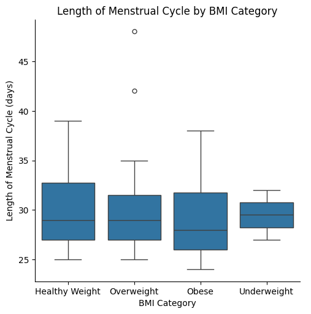

```python
# cause on the x-axis, outcome on the y-axis
sns.catplot(data = clean_df, x = "BMI_Cat", y = "LengthofCycle", kind = "box") # create box plot
# plt.xticks(rotation = 45) # rotate x-axis labels
plt.xlabel("BMI Category") # change x-axis label
plt.ylabel("Length of Menstrual Cycle (days)") # change y-axis label
plt.title("Length of Menstrual Cycle by BMI Category") # change title
plt.show()
```

**QUESTION**: How to fix this skew? What does it mean for our data?

### Age

```python
clean_df["Age"].unique()
clean_df["Age"].min() # 21.0
clean_df["Age"].max() # 43.0
```

```
43
```

First, let's find the square root of 142 (the number of data points in the "Age" column to determine how many bins our histogram should have.

```python
math.sqrt(142) # 11.92
```

```
11.916375287812984
```

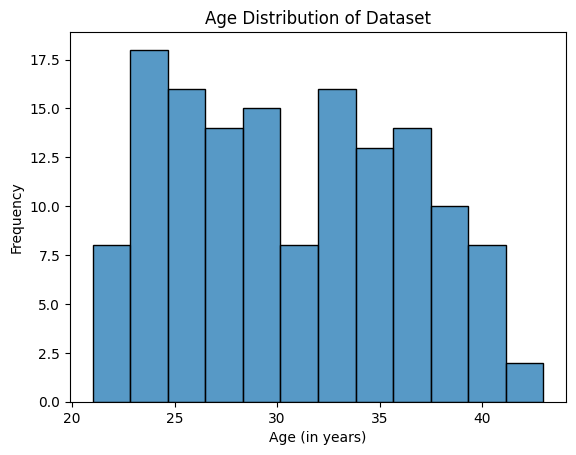

```python
# histograms with seaborn
sns.histplot(clean_df["Age"], bins = 12)
plt.xlabel("Age (in years)") # change x-axis label
plt.ylabel("Frequency") # change y-axis label
plt.title("Age Distribution of Dataset") # change title
plt.show()
```

Now, let's see if a scatterplot indicates a relationship between Age and Menstrual Cycle length in our dataset.

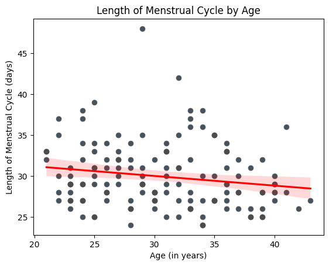

```python
sns.scatterplot(data = clean_df, x = "Age", y = "LengthofCycle")
sns.regplot(data = clean_df, x = "Age", y = "LengthofCycle", color = ".3", line_kws=dict(color="r"))
plt.xlabel("Age (in years)") # change x-axis label
plt.ylabel("Length of Menstrual Cycle (days)") # change y-axis label
plt.title("Length of Menstrual Cycle by Age") # change title
plt.show()
```

The above plot displays a very slight negative linear relationship (negative slope), indicating that as age increases, the length of one's menstrual cycle decreases.

This is represented in past research, which states that the length of menstrual cycles tends to decrease as people age, until they reach ages over 50 years old, wherein average cycle length increases.

Given that the current sample's maximum age is only 43, this increase in length later in life is not represented in this dataset.

# Statistical analysis

## Analysis of relationship between demographic variables and cycle length

```python
# # Importing library
# from scipy.stats import f_oneway

# # Conduct the one-way ANOVA
# f_oneway(performance1, performance2, performance3, performance4)
```

### Correlation matrix

With seaborn's heatmap function, we can create a correlation matrix to see how the demographic variable BMI and Age relate to our main outcome variable CycleLength.

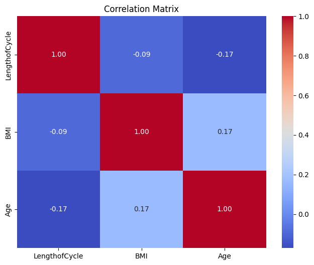

```python
# create correlation table between variables
corr = clean_df[['LengthofCycle', 'BMI', 'Age']].corr()

# plot the correlation matrix as a heatmap
plt.figure(figsize=(8, 6))
sns.heatmap(corr, annot=True, cmap='coolwarm', fmt=".2f")
plt.title('Correlation Matrix')
plt.show()
```